# Car Insurance Claim Prediction

Wenslo Dort

# **Summary**

This project aimed to predict whether a policyholder would file an insurance claim using a classification approach. After preparing and cleaning the data, I applied a variety of models, including logistic regression, LASSO, Ridge regression, and Random Forests. To address the strong class imbalance in the dataset, I performed threshold tuning and evaluated models using metrics beyond accuracy, including recall, F1 score, balanced accuracy, and AUC.

Logistic regression with backward stepwise selection and LASSO performed reasonably well when evaluated at optimized thresholds, showing modest improvements in identifying claimants. Ridge regression offered similar results, while Random Forest struggled with detecting the minority class, despite high overall accuracy. Although Boosting was considered for future work, it was not implemented due to time constraints. The project highlights the importance of appropriate metric selection, feature analysis, and threshold adjustment when dealing with imbalanced classification problems.

# **Purpose**

The purpose of this project is to predict whether a car insurance policyholder will file a claim. Insurance companies rely on this type of prediction to assess customer risk, manage costs, and design pricing strategies. Accurately identifying which policyholders are more likely to file a claim allows insurers to take proactive steps, such as adjusting policy terms or offering discounts to low-risk drivers. This analysis explores how well statistical learning methods can classify claim behavior based on vehicle characteristics, policyholder demographics, and safety features. It also highlights the challenges with modeling imbalanced data and underlines the importance of choosing evaluation metrics suited to real-world applications.

Questions that this project aim to answer are:

- What are the most important features that influence the likelihood of a policyholder filing a claim?
- How do different modeling techniques compare in their ability to classify claim vs. no-claim policyholders?

# **Data**

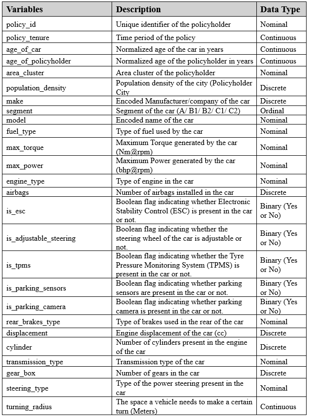

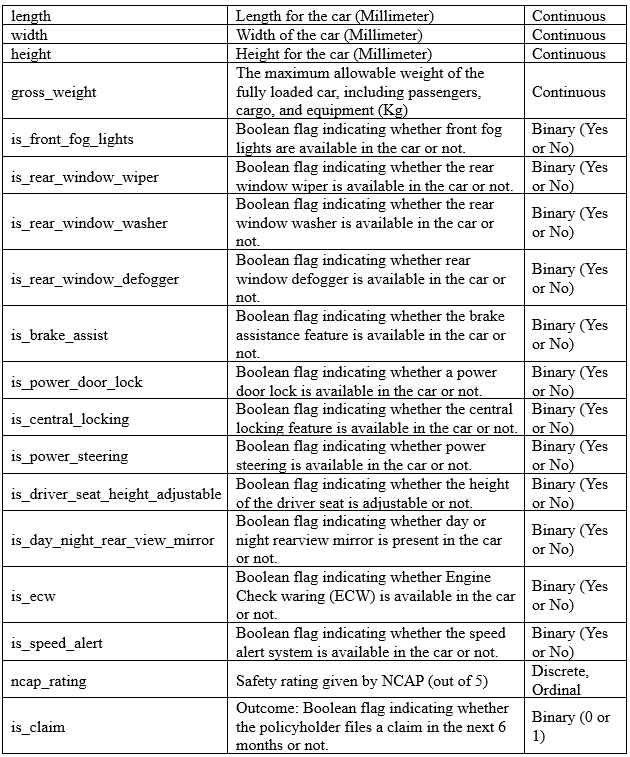

This insurance claim data set is from [Kaggle](https://www.kaggle.com/datasets/ifteshanajnin/carinsuranceclaimprediction-classification), but it seems that it was taken from [Analytics Vidhya](https://www.analyticsvidhya.com/datahack/contest/dataverse/), India’s largest data science community platform. This was used for a hackathon. We have a dimension of 58592 observations of 44 variables. There are too many variables to consider. Mostly have to use a correlation chart and content knowledge to help me determine which variables are the most important that could accurately determine whether a policyholder will file an insurance claim within the next six months.

* Note: The “segment” variable in the dataset is used to classify vehicles based on characteristics such as size, body type, and market positioning. Segments such as A, B1, B2, C1, C2, and Utility represent different vehicle classes defined by factors like car size, price, comfort level, and performance.

- Segment A (Mini cars): Small-sized vehicles primarily designed for city commuting, fuel efficiency, and ease of parking
- Segment B (Hatchback): Slightly larger than mini cars.
  - B1: Lower sub-segment—basic subcompact models
  - B2: Upper sub-segment—higher-end, more feature-rich subcompact models
- Segment C (Medium/compact cars): These family-oriented vehicles provide enhanced comfort, space, and features, distinguishing them from B-segment cars.
  - C1: Basic compact car variants.
  - C2: Premium compact variants offering enhanced features, safety, and comfort.
- Utility Segment: Includes SUVs, crossovers, pickup trucks, or utility-focused models designed for versatility and off-road capability.

We can see below that there is no missing values for each features. Now let’s see the structure of the data.

Missing Values in Training Dataset

| Variable | Missing_Values |
| --- | --- |
| policy_id | 0 |
| policy_tenure | 0 |
| age_of_car | 0 |
| age_of_policyholder | 0 |
| area_cluster | 0 |
| population_density | 0 |
| make | 0 |
| segment | 0 |
| model | 0 |
| fuel_type | 0 |
| max_torque | 0 |
| max_power | 0 |
| engine_type | 0 |
| airbags | 0 |
| is_esc | 0 |
| is_adjustable_steering | 0 |
| is_tpms | 0 |
| is_parking_sensors | 0 |
| is_parking_camera | 0 |
| rear_brakes_type | 0 |
| displacement | 0 |
| cylinder | 0 |
| transmission_type | 0 |
| gear_box | 0 |
| steering_type | 0 |
| turning_radius | 0 |
| length | 0 |
| width | 0 |
| height | 0 |
| gross_weight | 0 |
| is_front_fog_lights | 0 |
| is_rear_window_wiper | 0 |
| is_rear_window_washer | 0 |
| is_rear_window_defogger | 0 |
| is_brake_assist | 0 |
| is_power_door_locks | 0 |
| is_central_locking | 0 |
| is_power_steering | 0 |
| is_driver_seat_height_adjustable | 0 |
| is_day_night_rear_view_mirror | 0 |
| is_ecw | 0 |
| is_speed_alert | 0 |
| ncap_rating | 0 |
| is_claim | 0 |

# **Summary Statistics**

Summary Statistics for Numerical Variables

| policy_tenure | age_of_car | age_of_policyholder | population_density | turning_radius | length | width | height | gross_weight | displacement | airbags | cylinder | gear_box | ncap_rating |
| --- | --- | --- | --- | --- | --- | --- | --- | --- | --- | --- | --- | --- | --- |
| Min. :0.002735 | Min. :0.00000 | Min. :0.2885 | Min. : 290 | Min. :4.500 | Min. :3445 | Min. :1475 | Min. :1475 | Min. :1051 | Min. : 796 | Min. :1.000 | Min. :3.000 | Min. :5.000 | Min. :0.00 |
| 1st Qu.:0.210250 | 1st Qu.:0.02000 | 1st Qu.:0.3654 | 1st Qu.: 6112 | 1st Qu.:4.600 | 1st Qu.:3445 | 1st Qu.:1515 | 1st Qu.:1475 | 1st Qu.:1185 | 1st Qu.: 796 | 1st Qu.:2.000 | 1st Qu.:3.000 | 1st Qu.:5.000 | 1st Qu.:0.00 |
| Median :0.573792 | Median :0.06000 | Median :0.4519 | Median : 8794 | Median :4.800 | Median :3845 | Median :1735 | Median :1530 | Median :1335 | Median :1197 | Median :2.000 | Median :4.000 | Median :5.000 | Median :2.00 |
| Mean :0.611246 | Mean :0.06942 | Mean :0.4694 | Mean :18827 | Mean :4.853 | Mean :3850 | Mean :1672 | Mean :1553 | Mean :1385 | Mean :1162 | Mean :3.137 | Mean :3.627 | Mean :5.245 | Mean :1.76 |
| 3rd Qu.:1.039104 | 3rd Qu.:0.11000 | 3rd Qu.:0.5481 | 3rd Qu.:27003 | 3rd Qu.:5.000 | 3rd Qu.:3995 | 3rd Qu.:1755 | 3rd Qu.:1635 | 3rd Qu.:1510 | 3rd Qu.:1493 | 3rd Qu.:6.000 | 3rd Qu.:4.000 | 3rd Qu.:5.000 | 3rd Qu.:3.00 |
| Max. :1.396641 | Max. :1.00000 | Max. :1.0000 | Max. :73430 | Max. :5.200 | Max. :4300 | Max. :1811 | Max. :1825 | Max. :1720 | Max. :1498 | Max. :6.000 | Max. :4.000 | Max. :6.000 | Max. :5.00 |

The distribution of **policy_tenure** is bimodal, featuring one significant peak around 0, which represents newer customers, and another peak around 1, indicating long-term policyholders. This suggests that the dataset includes both new and loyal customers, who may exhibit different behaviors when filing claims. The histogram of **age_of_car** is significantly right-skewed, indicating that the majority of vehicles are new. The claim risk may be lower due to the presence of newer technologies and features, as very few vehicles are older than 0.25 on the normalized scale. Additionally, the **age_of_policyholder** variable exhibits a right-skewed distribution, with the majority of policyholders falling within the range of 0.3 to 0.5 on the normalized scale, which is likely indicative of younger to middle-aged individuals.

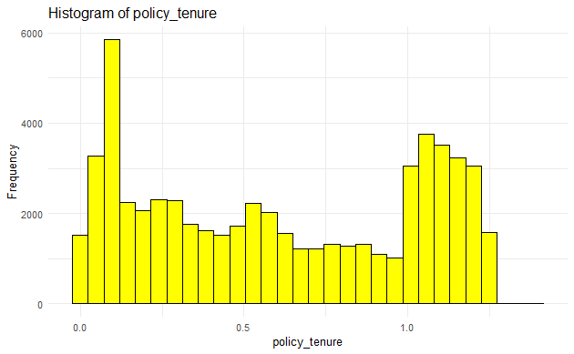

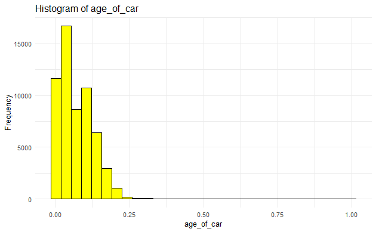

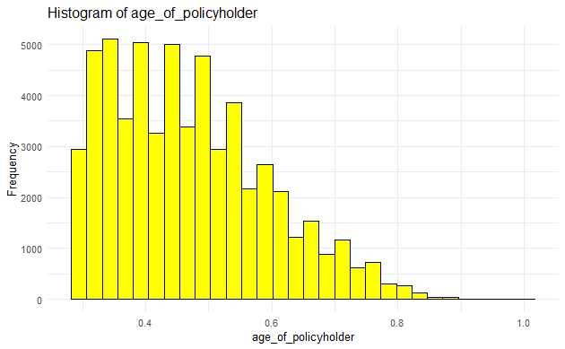

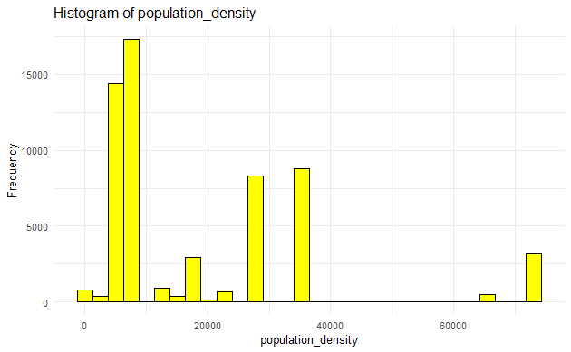

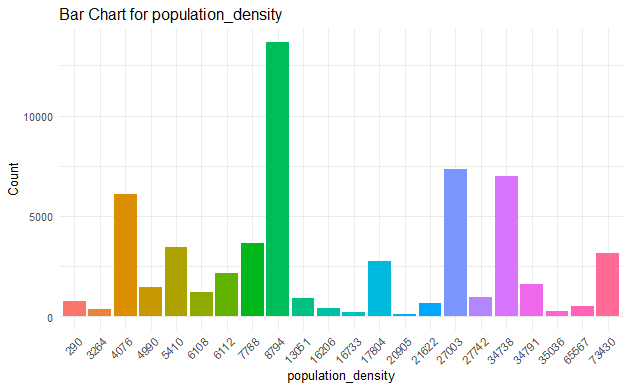

The bar charts depicting the discrete variables offer valuable insights into the physical and safety-related features of the vehicles in the dataset. Regarding **turning_radius**, the most commonly observed values are 4.6 m, 4.8 m, and 5.2 m, indicating a blend of compact and moderately maneuverable vehicles. The **length**, **width**, and **height** variables show distinct and diverse groupings, such as 3445 mm, 3845 mm, and 4300 mm for length; 1515 mm, 1735 mm, and 1790 mm for width; and 1475 mm, 1530 mm, and 1635 mm for height. These sets indicate a rich diversity in vehicle body types, likely ranging from hatchbacks to sedans and compact SUVs.

Other variables like **airbags**, **cylinder**, and **gear_box** further reveal vehicle specifications. Most vehicles have 2 or 6 airbags, indicating a balanced focus on the owner’s safety. Majority of the cars have 4 cylinders, which is standard, and a 5 gearbox is the most common transmission type. The **ncap_rating** variable shows many vehicles scoring 0, 2, or 3, suggesting that while some cars meet reasonable safety standards, there is a clear and urgent need for improvement in crash protection and safety assurance across the dataset.

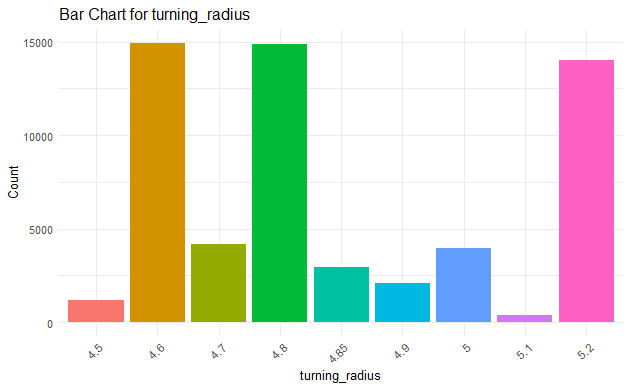

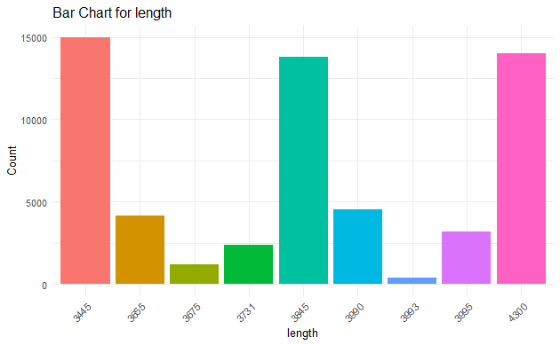

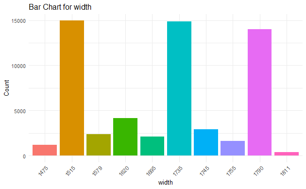

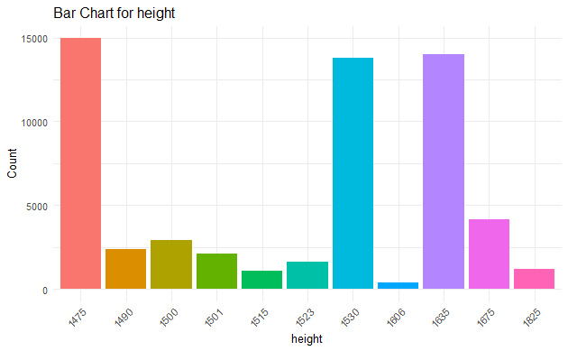

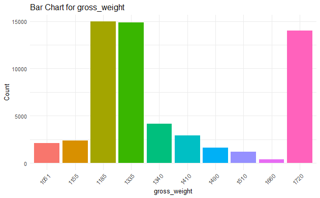

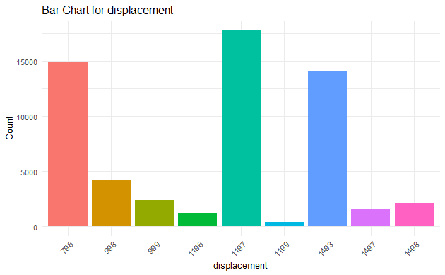

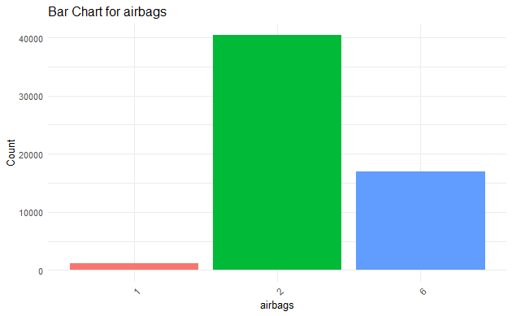

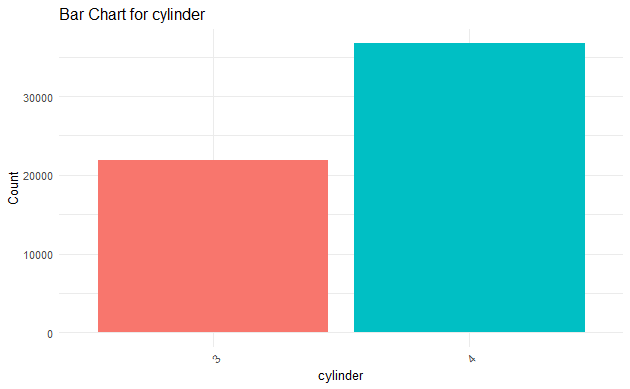

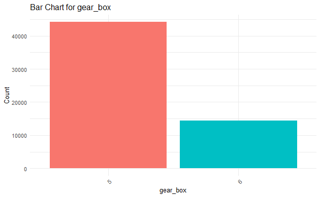

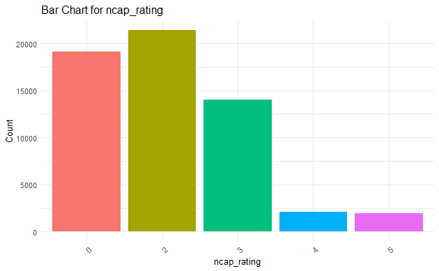

For the **area_cluster**, the highest frequency occurs in area cluster C8, indicating it has the highest concentration of policyholders. C2, C5, and C3 follow it. Other area clusters have relatively lower frequencies; C15 through C22, C4, and C6 are the lowest. For the **make** variable, Manufacturer 1 is the biggest producer of cars, producing over 38,000 cars; this suggests that consumers prefer Manufacturer 1, likely due to affordability and reliability. Manufacturer 3 is the second largest car producer, with nearly 15,000 vehicles, while manufacturers 2, 4, and 5 each produced under 2,500 cars — possibly reflecting lower popularity, higher prices, or niche appeal.  
The bar chart for **model** shows that models M1, M4, and M6 are the most common choices, while M3, M9, M5, M10, and M2 are the least common. The **fuel_type** bar chart illustrates the distribution of cars by fuel type: Petrol holds a slight edge, closely followed by CNG and Diesel, highlighting diverse consumer preferences. For **engine_type**, the most frequent are the F8D Petrol Engine, 1.5 L U2 CRDi, and K Series Dual Jet. These popular engine types suggest a balance between fuel economy, maintenance costs, and performance. Regarding **rear_brakes_type**, Drum brakes are significantly more common than Disc brakes. While drum brakes are more economical and durable, disc brakes provide better performance and are more frequently located in higher-end or sportier models. For **steering_type**, Power steering dominates, followed by Electric, while Manual steering is rarely used. This may reflect both technological advancement and consumer preference for ease of driving.  
The **transmission_type** distribution shows that Manual transmissions are significantly more common than Automatic ones, indicating that either manual cars are more affordable or preferred by the target market. In the **segment** variable, B2 and A are the most common, followed by C2, suggesting a concentration of vehicles in compact and subcompact categories — often popular for urban use. The lower frequencies in segments like Utility, B1, and C1 suggest these are less popular, possibly due to pricing.  
Regarding **max_power**, the most frequent outputs are 88.50bhp@6000rpm, 40.36bhp@6000rpm, and 113.45bhp@4000rpm, making up nearly 80% of the dataset. These values point toward vehicles with moderate to high power, likely reflecting consumer preferences for balanced performance and efficiency. Similarly, for ** max_torque **, the most common values are 113Nm@4400rpm, 60Nm@3500rpm, and 250Nm@2750rpm. These levels of torque are consistent with small to mid-sized engines suitable for everyday driving conditions. Lastly, the mixture of specific characteristics—4300 mm length, 1790 mm width, 1635 mm height, 1720 kg gross weight, 1493 cc displacement, and 6 airbags—aligns with typical subcompact SUVs. These vehicles offer safety and space, making them ideal for families and urban drivers. Their popularity in the dataset indicates a substantial market segment that values modern features without entering the whole SUV class.

area_cluster

| Category | Frequency |
| --- | --- |
| C8 | 13654 |
| C2 | 7342 |
| C5 | 6979 |
| C3 | 6101 |
| C14 | 3660 |
| C13 | 3423 |
| C10 | 3155 |
| C9 | 2734 |
| C7 | 2167 |
| C12 | 1589 |

make

| Category | Frequency |
| --- | --- |
| 1 | 38126 |
| 3 | 14018 |
| 2 | 2373 |
| 5 | 2114 |
| 4 | 1961 |

model

| Category | Frequency |
| --- | --- |
| M1 | 14948 |
| M4 | 14018 |
| M6 | 13776 |
| M8 | 4173 |
| M7 | 2940 |
| M3 | 2373 |
| M9 | 2114 |
| M5 | 1598 |
| M10 | 1209 |
| M2 | 1080 |

fuel_type

| Category | Frequency |
| --- | --- |
| Petrol | 20532 |
| CNG | 20330 |
| Diesel | 17730 |

engine_type

| Category | Frequency |
| --- | --- |
| F8D Petrol Engine | 14948 |
| 1.5 L U2 CRDi | 14018 |
| K Series Dual jet | 13776 |
| K10C | 4173 |
| 1.2 L K Series Engine | 2940 |
| 1.0 SCe | 2373 |
| i-DTEC | 2114 |
| 1.5 Turbocharged Revotorq | 1598 |
| G12B | 1209 |
| 1.2 L K12N Dualjet | 1080 |

rear_brakes_type

| Category | Frequency |
| --- | --- |
| Drum | 44574 |
| Disc | 14018 |

transmission_type

| Category | Frequency |
| --- | --- |
| Manual | 38181 |
| Automatic | 20411 |

steering_type

| Category | Frequency |
| --- | --- |
| Power | 33502 |
| Electric | 23881 |
| Manual | 1209 |

segment

| Category | Frequency |
| --- | --- |
| B2 | 18314 |
| A | 17321 |
| C2 | 14018 |
| B1 | 4173 |
| C1 | 3557 |
| Utility | 1209 |

max_power

| Category | Frequency |
| --- | --- |
| 88.50bhp@6000rpm | 17796 |
| 40.36bhp@6000rpm | 14948 |
| 113.45bhp@4000rpm | 14018 |
| 55.92bhp@5300rpm | 4173 |
| 67.06bhp@5500rpm | 2373 |
| 97.89bhp@3600rpm | 2114 |
| 88.77bhp@4000rpm | 1598 |
| 61.68bhp@6000rpm | 1209 |
| 118.36bhp@5500rpm | 363 |

max_torque

| Category | Frequency |
| --- | --- |
| 113Nm@4400rpm | 17796 |
| 60Nm@3500rpm | 14948 |
| 250Nm@2750rpm | 14018 |
| 82.1Nm@3400rpm | 4173 |
| 91Nm@4250rpm | 2373 |
| 200Nm@1750rpm | 2114 |
| 200Nm@3000rpm | 1598 |
| 85Nm@3000rpm | 1209 |
| 170Nm@4000rpm | 363 |

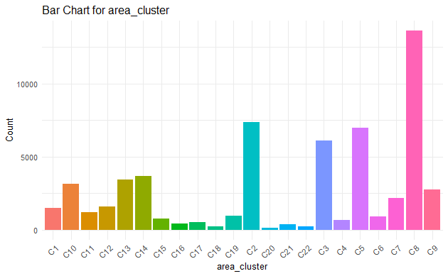

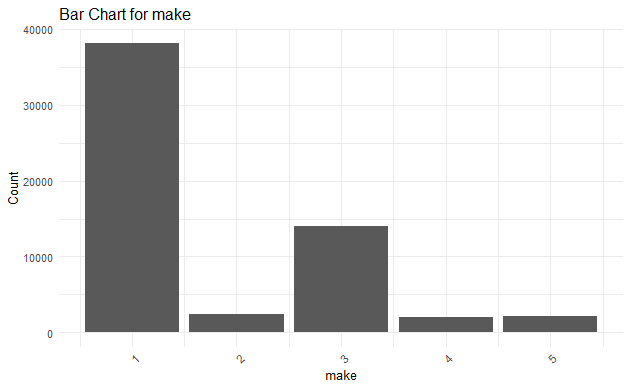

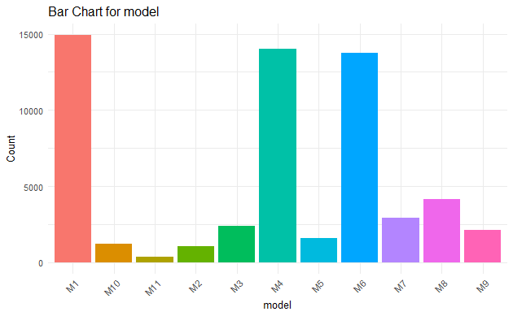

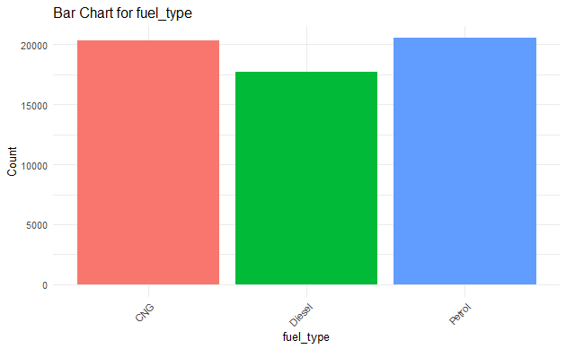

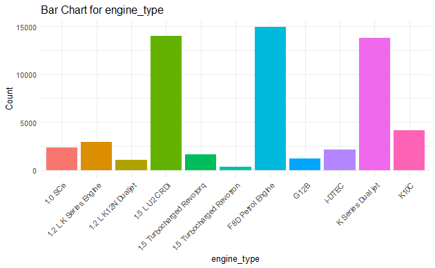

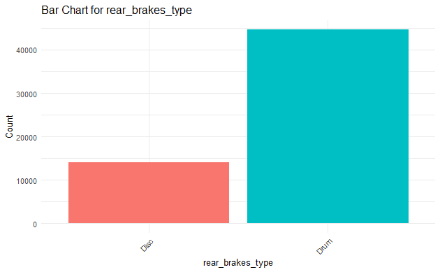

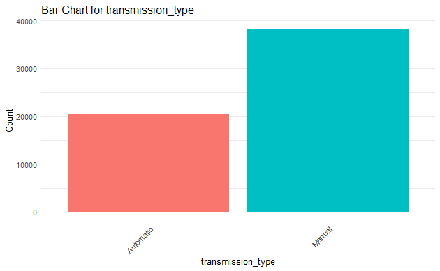

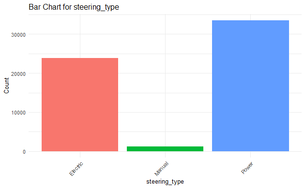

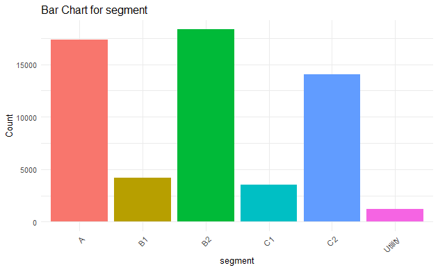

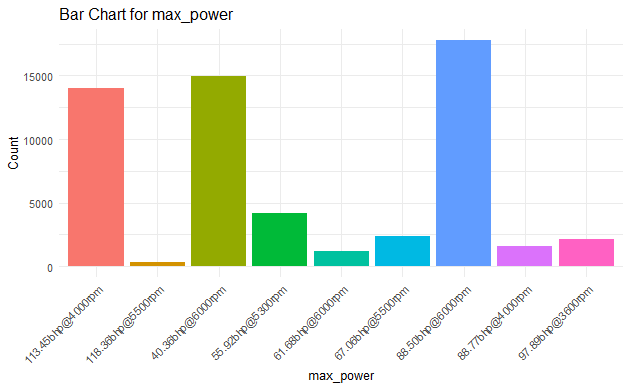

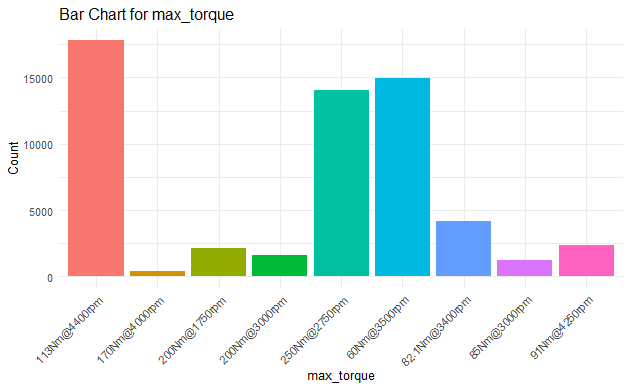

The table below summarizes the frequency of binary (Yes/No) variables, indicating the presence or absence of specific car features. These frequencies assist in understanding common practices, optional features, and consumer preferences regarding car safety and comfort.The variable **“is_claim”** shows a very low frequency, with only 6.4% responding “Yes,” confirming that claims are relatively rare in this dataset.Both Speed alerts **(is_speed_alert)** and Power steering **(is_power_steering)** are highly general, with nearly all cars equipped, signifying it as a common feature in the dataset.  
Tyre pressure monitoring systems **(is_tpms)** and Electronic Stability Control **(is_esc)** operate at lower frequencies, possibly due to cost-saving measures or consumer choices based on budget constraints or necessity.

Summary of Binary Variables (Yes/No Counts)

|  | Yes | No |
| --- | --- | --- |
| is_esc | 18401 | 40191 |
| is_adjustable_steering | 35526 | 23066 |
| is_tpms | 14018 | 44574 |
| is_parking_sensors | 56219 | 2373 |
| is_parking_camera | 22888 | 35704 |
| is_front_fog_lights | 33928 | 24664 |
| is_rear_window_wiper | 16958 | 41634 |
| is_rear_window_washer | 16958 | 41634 |
| is_rear_window_defogger | 20515 | 38077 |
| is_brake_assist | 32177 | 26415 |
| is_power_door_locks | 42435 | 16157 |
| is_central_locking | 42435 | 16157 |
| is_power_steering | 57383 | 1209 |
| is_driver_seat_height_adjustable | 34291 | 24301 |
| is_day_night_rear_view_mirror | 22283 | 36309 |
| is_ecw | 42435 | 16157 |
| is_speed_alert | 58229 | 363 |
| is_claim | 3748 | 54844 |